# Image Characteristics

As I've not used virtualenvs much before, making sure that it's working in the notebook:

```python
!pip freeze
```

```
Pillow==2.7.0
numpy==1.9.1
py==1.4.26
pytest==2.6.4
scikit-image==0.10.1
scikit-learn==0.15.2
scipy==0.14.0
six==1.8.0
tox==1.8.1
virtualenv==12.0.4
```

Looks good. Checking path:

```python
import sys
print(sys.path)
```

```
['', '/home/gavin/repositories/neukrill_venv/lib/python3.4/site-packages', '', '/usr/lib/python34.zip', '/usr/lib/python3.4', '/usr/lib/python3.4/plat-linux', '/usr/lib/python3.4/lib-dynload', '/home/gavin/.local/lib/python3.4/site-packages', '/usr/lib/python3.4/site-packages', '/usr/lib/python3.4/s…
```

Tools repository has been added succesfully.

# Aims

Want to investigate the images in various ways. Want to simply look at the different classes and make a record of the different sizes. Also would like to investigate other factors, like image statistics and visualize similarities using dimensionality reduction. Making a list:

- List the classes and superclasses
- Look at examples from different classes
- Distribution of image dimensions (heatmap)
- Class proportions
- Image statistics (define more accurately when you get here)
- Visualize similarities (dimensionality reduction etc)

First, parsing the images:

```python
cd ..
```

```
/home/gavin/repositories/neukrill-net-work
```

```python
import neukrill_net.utils
```

```python
settings = neukrill_net.utils.parse_settings('settings.json')
```

```python
import train
```

```python
imagedict = train.gather_images(settings['train_data_dir'])
```

# Classes

They are described in the [pdf provided with the data](https://kaggle2.blob.core.windows.net/competitions-data/kaggle/3978/plankton_identification.pdf?sv=2012-02-12&se=2015-01-11T21%3A24%3A07Z&sr=b&sp=r&sig=VW1F1UnNvUs3H0KHYRoxGakhlla3SHCYOk9iImymihs%3D). In that pdf you can also see the superclasses these are divided into. We can get them from the filenames as follows:

```python
classes = list(imagedict.keys())
# copy the list
temp_classes = classes[:]
while len(temp_classes) > 0:
    # take three off the temp list on each iteration and print them
    # with tabs in between, catching the last few with the if
    if len(temp_classes) < 3:
        print("\t".join([temp_classes.pop() for i in range(len(temp_classes))]))
    else:
        print("\t".join([temp_classes.pop() for i in range(3)]))
```

```
detritus_other	hydromedusae_narco_dark	copepod_cyclopoid_oithona_eggs
copepod_cyclopoid_oithona	ctenophore_cestid	unknown_unclassified
hydromedusae_haliscera_small_sideview	copepod_calanoid_eucalanus	echinoderm_seacucumber_auricularia_larva
copepod_calanoid_large_side_antennatucked	shrimp-like_other	echinopluteus
hydromedusae_haliscera	hydromedusae_typeE	hydromedusae_narco_young
hydromedusae_other	copepod_other	protist_fuzzy_olive
fish_larvae_myctophids	chordate_type1	tunicate_salp_chains
copepod_calanoid_large	siphonophore_other_parts	invertebrate_larvae_other_A
siphonophore_calycophoran_sphaeronectes	artifacts	euphausiids_young
chaetognath_sagitta	trichodesmium_tuft	polychaete
chaetognath_non_sagitta	amphipods	shrimp_sergestidae
tunicate_doliolid	appendicularian_slight_curve	copepod_calanoid_small_longantennae
fish_larvae_leptocephali	tornaria_acorn_worm_larvae	trichodesmium_multiple
unknown_blobs_and_smudges	fish_larvae_thin_body	siphonophore_calycophoran_sphaeronectes_young
copepod_calanoid_octomoms	decapods	pteropod_butterfly
siphonophore_calycophoran_rocketship_adult	acantharia_protist_big_center	detritus_filamentous
hydromedusae_partial_dark	siphonophore_calycophoran_sphaeronectes_stem	acantharia_protist_halo
tunicate_doliolid_nurse	hydromedusae_typeD_bell_and_tentacles	stomatopod
appendicularian_fritillaridae	fish_larvae_deep_body	copepod_calanoid_flatheads
shrimp_caridean	hydromedusae_shapeB	copepod_calanoid_eggs
trichodesmium_puff	echinoderm_larva_pluteus_brittlestar	radiolarian_chain
hydromedusae_liriope	echinoderm_larva_pluteus_urchin	siphonophore_physonect_young
hydromedusae_solmaris	hydromedusae_aglaura	copepod_cyclopoid_copilia
diatom_chain_tube	invertebrate_larvae_other_B	pteropod_theco_dev_seq
ctenophore_cydippid_tentacles	artifacts_edge	protist_other
protist_noctiluca	hydromedusae_bell_and_tentacles	diatom_chain_string
ephyra	crustacean_other	appendicularian_straight
echinoderm_larva_pluteus_early	siphonophore_calycophoran_abylidae	unknown_sticks
hydromedusae_narcomedusae	copepod_calanoid	hydromedusae_h15
ctenophore_lobate	detritus_blob	hydromedusae_shapeA_sideview_small
fecal_pellet	siphonophore_calycophoran_rocketship_young	fish_larvae_very_thin_body
trochophore_larvae	hydromedusae_sideview_big	siphonophore_partial
heteropod	shrimp_zoea	hydromedusae_typeD
euphausiids	trichodesmium_bowtie	protist_star
echinoderm_larva_seastar_bipinnaria	hydromedusae_shapeA	siphonophore_physonect
fish_larvae_medium_body	hydromedusae_solmundella	acantharia_protist
echinoderm_larva_pluteus_typeC	echinoderm_larva_seastar_brachiolaria	copepod_calanoid_frillyAntennae
protist_dark_center	hydromedusae_typeF	radiolarian_colony
pteropod_triangle	tunicate_partial	tunicate_salp
appendicularian_s_shape	jellies_tentacles	ctenophore_cydippid_no_tentacles
chaetognath_other
```

# Super Classes

We want a list of these, because then we can split up the above with some work. Think the only option is to write it by hand. There is a problem with this, because *the classes don't all have their superclass in their name*. Most of them do, but not all. Examples are some Shrimp-likes, others in crustaceans, heteropods and fecal pellets. So these superclasses are **incomplete**. To fix it we'd need to make a dictionary, with each of the classes sorted into the right corresponding superclasses.

```python
superclasses = ['tricho', 'diatom', 'chordate', 'polychaete',
                'ctenophore', 'siphonophore', 'hydromedusae',
                'tunicate', 'ephyra', 'jellies', 'appendicularian',
                'fish', 'copepod', 'shrimp', 'chaetognath',
                'pteropod', 'detritus', 'larvae', 'echinoderm',
                'unknown']
```

```python
# splitting the classes into approximate super classes
split_by_superclass = {}
for sc in superclasses:
    split_by_superclass[sc] = []
for c in classes:
    for sc in superclasses:
        if sc in c:
            split_by_superclass[sc] += [c]
```

# Viewing the images

Difficult to view this many images at the same time, even looking at single examples from each class would be hard. Going to look at examples from each superclass.

```python
from IPython.display import display
from IPython.display import Image
from IPython.display import HTML
```

```python
examples = imagedict[split_by_superclass[superclasses[0]][0]]
```

```python
for e in examples[:3]:
    s = """{0}""".format(superclasses[0])
    h = HTML(s)
    display(s)
    i = Image(e)
    display(i)
```

```
'tricho'
```

```
'tricho'
```

```
'tricho'
```

Then, iterating through the rest:

```
'tricho'
```

```
'tricho'
```

```
'tricho'
```

```
'diatom'
```

```
'diatom'
```

```
'diatom'
```

```
'chordate'
```

```
'chordate'
```

```
'chordate'
```

```
'polychaete'
```

```
'polychaete'
```

```
'polychaete'
```

```
'ctenophore'
```

```
'ctenophore'
```

```
'ctenophore'
```

```
'siphonophore'
```

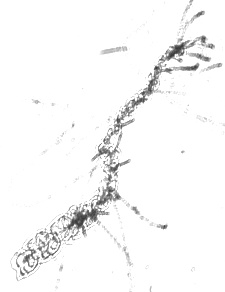

```
'siphonophore'
```

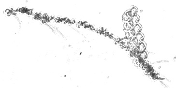

```
'siphonophore'
```

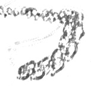

```
'hydromedusae'
```

```
'hydromedusae'
```

```
'hydromedusae'
```

```
'tunicate'
```

```
'tunicate'
```

```
'tunicate'
```

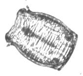

```
'ephyra'
```

```
'ephyra'
```

```
'ephyra'
```

```
'jellies'
```

```
'jellies'
```

```
'jellies'
```

```
'appendicularian'
```

```
'appendicularian'
```

```
'appendicularian'
```

```
'fish'
```

```
'fish'
```

```
'fish'
```

```
'copepod'
```

```
'copepod'
```

```
'copepod'
```

```
'shrimp'
```

```
'shrimp'
```

```
'shrimp'
```

```
'chaetognath'
```

```
'chaetognath'
```

```
'chaetognath'
```

```
'pteropod'
```

```
'pteropod'
```

```
'pteropod'
```

```
'detritus'
```

```
'detritus'
```

```
'detritus'
```

```
'larvae'
```

```
'larvae'
```

```
'larvae'
```

```
'echinoderm'
```

```
'echinoderm'
```

```
'echinoderm'
```

```
'unknown'
```

```
'unknown'
```

```
'unknown'
```

```python
for sc in superclasses:
    examples = imagedict[split_by_superclass[sc][0]]
    for e in examples[:3]:
        s = """{0}""".format(sc)
        h = HTML(s)
        display(s)
        i = Image(e)
        display(i)
```

# Image Dimensions

To do this, first we're going to have to load these images into numpy:

```python
import skimage.io
import numpy as np
```

```python
image_array_dict = {}
for i,c in enumerate(classes):
    #print("class: {0} of 120: {1}".format(i,c))
    image_fpaths = imagedict[c]
    # dictionary will contain lists of numpy arrays
    image_array_dict[c] = []
    # iterate over all paths adding to list in dictionary
    for fpath in image_fpaths:
        image_array_dict[c].append(skimage.io.imread(fpath))
```

```python
# build a list of dimensions
dimensions = [image_array.shape for imagelist in list(image_array_dict.values()) for image_array in imagelist]
```

My code is [copied shamelessly from stackexchange](https://stackoverflow.com/questions/2369492/generate-a-heatmap-in-matplotlib-using-a-scatter-data-set).

```python
%matplotlib inline
import matplotlib.pyplot as plt
```

```python
plt.rcParams['figure.figsize'] = 12, 8
plt.rcParams['axes.grid'] = True
plt.set_cmap('brg')
```

```python
x,y = zip(*dimensions)
```

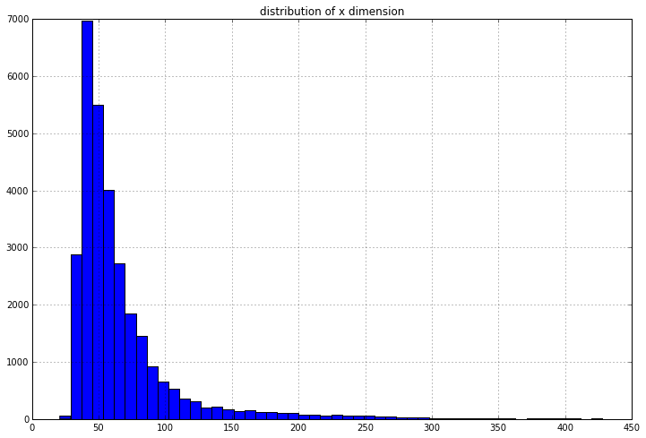

```python
plt.title("distribution of x dimension")
h = plt.hist(x, bins=50)
```

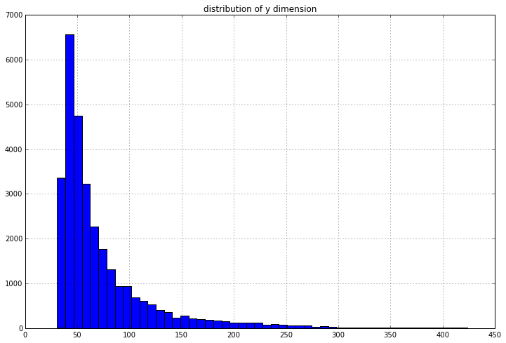

```python
plt.title("distribution of y dimension")
h = plt.hist(y, bins=50)
```

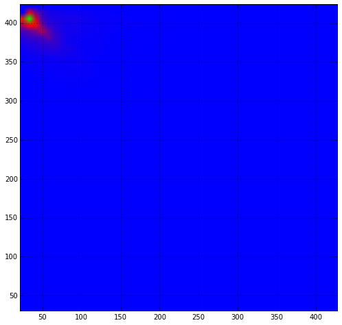

```python
heatmap, xedges, yedges = np.histogram2d(x, y, bins=50)
extent = [xedges[0], xedges[-1], yedges[0], yedges[-1]]

plt.title("Joint distribution")
plt.clf()
plt.imshow(heatmap, extent=extent)
plt.show()
```

Looks like a [exponential-logarithmic distribution](https://en.wikipedia.org/wiki/Exponential-logarithmic_distribution).

# Class Proportions

How are the classes distributed? Do we have way more of some examples than others?

```python
# dictionary of classes as keys and number of examples for values
n_examples = {}
for c in classes:
    n_examples[c] = len(imagedict[c])
```

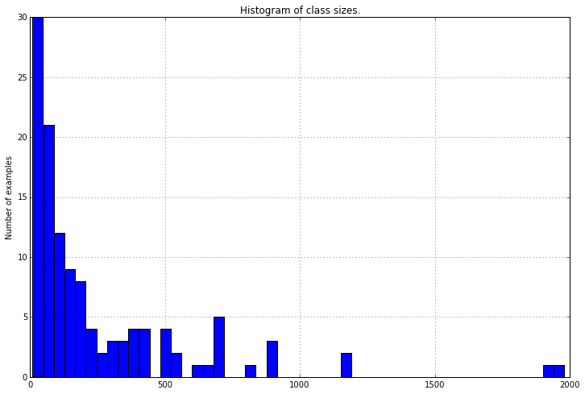

```python
plt.title("Histogram of class sizes.")
plt.ylabel("Number of examples")
h=plt.hist(list(n_examples.values()),bins=50)
```

That doesn't look good, some classes have *very few examples*. How bad is it? Let's look at only the classes with less than 250 examples:

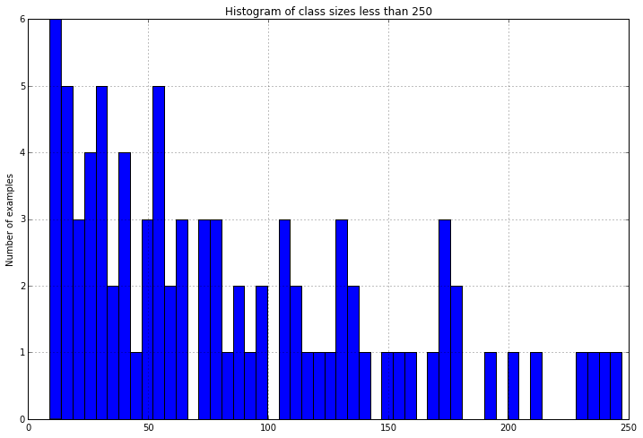

```python
plt.title("Histogram of class sizes less than 250")
plt.ylabel("Number of examples")
lessthan250 = [n for n in list(n_examples.values()) if n < 250]
h=plt.hist(lessthan250,bins=50)
```

That's very bad, quite a few classes have only about 10 examples. Which classes are they?

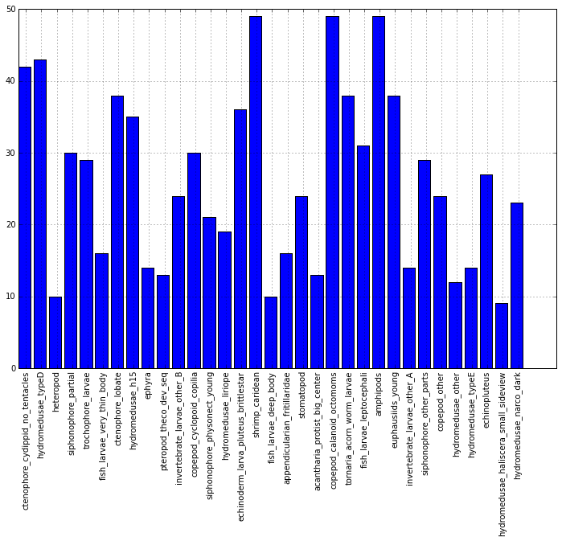

```python
ks = [k for k in classes if n_examples[k] < 50]
lessthan50 = [n_examples[k] for k in ks]
fig, ax = plt.subplots()
ind = range(len(lessthan50))
ax.bar(ind,lessthan50)
ax.set_xticks(np.array(ind)+0.5)
ax.set_xticklabels(ks,rotation=90)
plt.show()
```